# Reproducible Research : Course Project 1

Akshay Bapte 29/05/2020

## Introduction

It is now possible to collect a large amount of data about personal movement using activity monitoring devices such as a Fitbit, Nike Fuelband, or Jawbone Up. These type of devices are part of the “quantified self” movement – a group of enthusiasts who take measurements about themselves regularly to improve their health, to find patterns in their behavior, or because they are tech geeks. But these data remain under-utilized both because the raw data are hard to obtain and there is a lack of statistical methods and software for processing and interpreting the data.

This assignment makes use of data from a personal activity monitoring device. This device collects data at 5 minute intervals through out the day. The data consists of two months of data from an anonymous individual collected during the months of October and November, 2012 and include the number of steps taken in 5 minute intervals each day.

## Data

The data for this assignment : [Activity Monitoring Data](https://d396qusza40orc.cloudfront.net/repdata%2Fdata%2Factivity.zip)

The variables included in this dataset are:

- **steps**: Number of steps taking in a 5-minute interval (missing values are coded as NA)
- **date**: The date on which the measurement was taken in YYYY-MM-DD format
- **interval**: Identifier for the 5-minute interval in which measurement was taken

The dataset is stored in a comma-separated-value (CSV) file and there are a total of 17,568 observations in this dataset.

## Assignment Instructions

1.Code for reading in the dataset and/or processing the data

2.Histogram of the total number of steps taken each day

3.Mean and median number of steps taken each day

4.Time series plot of the average number of steps taken

5.The 5-minute interval that, on average, contains the maximum number of steps

6.Code to describe and show a strategy for imputing missing data

7.Histogram of the total number of steps taken each day after missing values are imputed

8.Panel plot comparing the average number of steps taken per 5-minute interval across weekdays and weekends

9.All of the R code needed to reproduce the results (numbers, plots, etc.) in the report

## Loading and preprocessing the data

```r
library(dplyr)
```

```r
library(ggplot2)
data <- read.csv("activity.csv")
summary(data)
```

```
##      steps                date          interval
##  Min.   :  0.00   2012-10-01:  288   Min.   :   0.0
##  1st Qu.:  0.00   2012-10-02:  288   1st Qu.: 588.8
##  Median :  0.00   2012-10-03:  288   Median :1177.5
##  Mean   : 37.38   2012-10-04:  288   Mean   :1177.5
##  3rd Qu.: 12.00   2012-10-05:  288   3rd Qu.:1766.2
##  Max.   :806.00   2012-10-06:  288   Max.   :2355.0
##  NA's   :2304     (Other)   :15840
```

```r
data$date <- as.Date(as.character(data$date), format = "%Y-%m-%d")
class(data$date)
```

```
## [1] "Date"
```

## What is mean total number of steps taken per day?

```r
steps_per_day <- data %>% group_by(date) %>% summarize(Total_steps = sum(steps))
head(steps_per_day)
```

```
## # A tibble: 6 x 2
##   date       Total_steps
##   <date>           <int>
## 1 2012-10-01          NA
## 2 2012-10-02         126
## 3 2012-10-03       11352
## 4 2012-10-04       12116
## 5 2012-10-05       13294
## 6 2012-10-06       15420
```

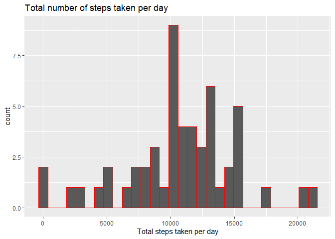

```r
plot1 <- ggplot(steps_per_day, aes(Total_steps)) + geom_histogram(colour = "red") +
  labs(title = "Total number of steps taken per day", x = "Total steps taken per day")
print(plot1)
```

Here is the mean of total number of steps taken per day :

```r
mean(steps_per_day$Total_steps, na.rm = TRUE)
```

```
## [1] 10766.19
```

Here is the median of total number of steps taken per day :

```r
median(steps_per_day$Total_steps, na.rm = TRUE)
```

```
## [1] 10765
```

## What is the average daily activity pattern?

A time series plot of the 5-minute interval (x-axis) and the average number of steps taken, averaged across all days (y-axis) :

```r
steps_per_interval <- data %>% group_by(interval) %>% summarize(Avg_steps = mean(steps, na.rm = TRUE))
head(steps_per_interval)
```

```
## # A tibble: 6 x 2
##   interval Avg_steps
##      <int>     <dbl>
## 1        0    1.72
## 2        5    0.340
## 3       10    0.132
## 4       15    0.151
## 5       20    0.0755
## 6       25    2.09
```

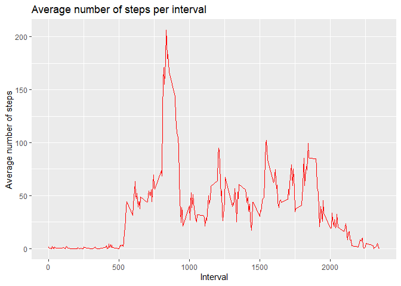

```r
plot2 <- ggplot(steps_per_interval, aes(interval, Avg_steps)) + geom_line(colour = "red") +
   labs(title = "Average number of steps per interval", x = "Interval", y = "Average number of steps")
print(plot2)
```

The 5-minute interval, on average across all the days in the dataset, which contains the maximum number of steps is :

```r
steps_per_interval[which.max(steps_per_interval$Avg_steps),]$interval
```

```
## [1] 835
```

## Imputing missing values

There are a number of days/intervals where there are missing values (coded as NA). The presence of missing days may introduce bias into some calculations or summaries of the data.

The total number of missing values in the data :

```r
sum(is.na(data$steps))
```

```
## [1] 2304
```

For imputing the missing values in the datasets, we are replacing the missing values with the mean for that 5-minute interval :

```r
steps_no_NA <- steps_per_interval$Avg_steps[match(data$interval, steps_per_interval$interval)]
sum(is.na(steps_no_NA))
```

```
## [1] 0
```

Creating a new dataset that is equal to the original dataset but with the missing data filled in :

```r
data_no_NA <- transform(data, steps = ifelse(is.na(data$steps), yes = steps_no_NA, no = data$steps))
Total_steps_no_NA <- data_no_NA %>% group_by(date) %>% summarize(Total_steps = sum(steps))
```

A histogram of the total number of steps taken each day :

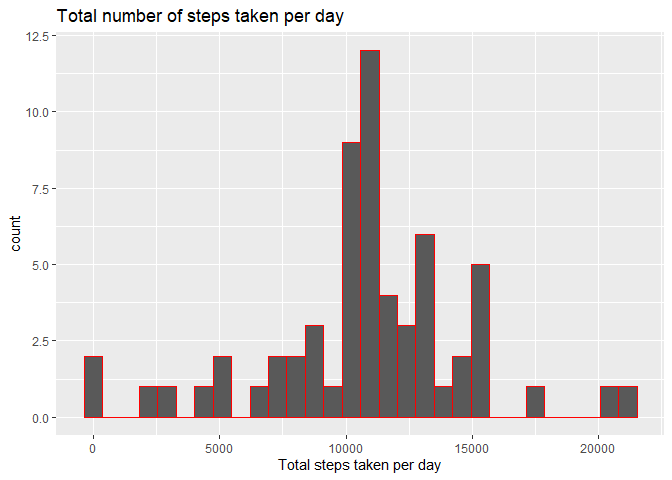

```r
ggplot(Total_steps_no_NA, aes(Total_steps)) + geom_histogram(colour = "red") +
  labs(title = "Total number of steps taken per day", x = "Total steps taken per day")
```

Mean and Median total number of steps taken per day :

```r
mean(Total_steps_no_NA$Total_steps)
```

```
## [1] 10766.19
```

```r
median(Total_steps_no_NA$Total_steps)
```

```
## [1] 10766.19
```

## Are there differences in activity patterns between weekdays and weekends?

Creating a new factor variable in the dataset with two levels – “weekday” and “weekend” indicating whether a given date is a weekday or weekend day :

```r
data$daytype <- sapply(data$date, function(x){
   if(weekdays(x) == "Saturday" | weekdays(x) == "Sunday") {
     y <- "Weekend"
   } else {
     y <- "Weekday"
   }

})
```

Making a panel plot containing a time series plot of the 5-minute interval (x-axis) and the average number of steps taken, averaged across all weekday days or weekend days (y-axis) :

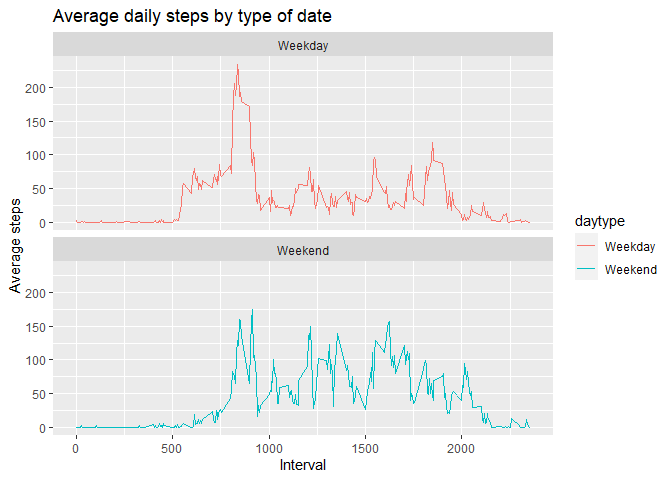

```r
steps_per_daytype <- data %>% group_by(interval, daytype) %>% summarize(Avg_steps = mean(steps, na.rm = TRUE))
ggplot(steps_per_daytype, aes(interval, Avg_steps, col = daytype )) + geom_line() + facet_wrap(~daytype, ncol = 1, nrow=2) + labs(title = "Average daily steps by type of date", x = "Interval", y = "Average steps")
```